# Лабораторная работа №17

Имитационное моделирование

Серёгина Ирина Андреевна

Российский университет дружбы народов, Москва, Россия

31 мая 2025

## Цель работы

Выполнить задания для самостоятельного выполнения.

## Задание

Реализовать следующие модели:

1. Модель работы вычислительного центра
2. Модель работы аэропорта
3. Модель работы морского порта

## Выполнение лабораторной работы

## Модель работы вычислительного центра

На вычислительном центре в обработку принимаются три класса заданий А, В и С. Исходя из наличия оперативной памяти ЭВМ задания классов А и В могут решаться одновременно, а задания класса С монополизируют ЭВМ. Задания класса А поступают через 20 ± 5 мин, класса В — через 20 ± 10 мин, класса С — через 28 ± 5 мин и требуют для выполнения: класс А — 20 ± 5 мин, класс В — 21 ± 3 мин, класс С — 28 ± 5 мин. Задачи класса С загружаются в ЭВМ, если она полностью свободна. Задачи классов А и В могут дозагружаться к решающей задаче. Смоделировать работу ЭВМ за 80 ч. Определить её загрузку

## Модель работы вычислительного центра

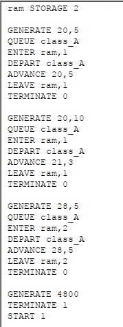

Модель работы вычислительного центра

## Модель работы вычислительного центра

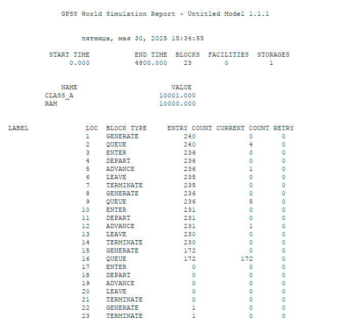

Отчёт модели работы вычислительного центра

## Модель работы вычислительного центра

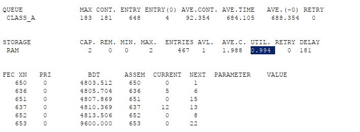

Отчёт модели работы вычислительного центра

## Модель работы аэропорта

Самолёты прибывают для посадки в район аэропорта каждые 10 ± 5 мин. Если взлетно- посадочная полоса свободна, прибывший самолёт получает разрешение на посадку. Если полоса занята, самолет выполняет полет по кругу и возвращается в аэропорт каждые 5 мин. Если после пятого круга самолет не получает разрешения на посадку, он отправляется на запасной аэродром. В аэропорту через каждые 10 ± 2 мин к взлетно -посадочной полосе выруливают готовые к взлёту самолёты и получают разрешение на взлёт, если полоса свободна. Для взлета и посадки самолёты занимают полосу ровно на 2 мин. Если при свободной полосе одновременно один самолёт прибывает для посадки, а другой — для взлёта, то полоса предоставляется взлетающей машине. Требуется: – выполнить моделирование работы аэропорта в течение суток; – подсчитать количество самолётов, которые взлетели, сели и были направлены на запасной аэродром; – определить коэффициент загрузки взлетно-посадочной полосы

## Модель работы аэропорта

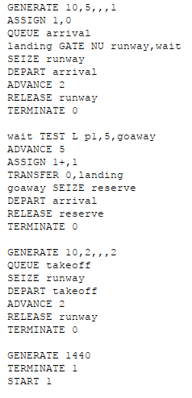

Модель работы аэропорта

## Модель работы аэропорта

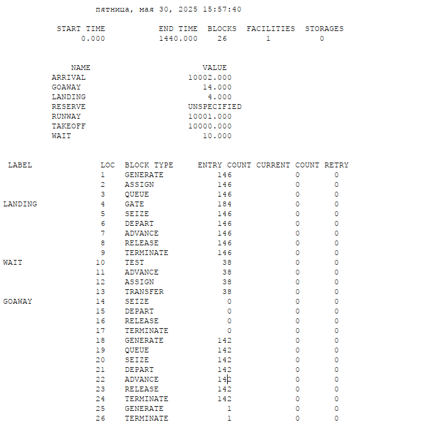

Отчёт модели работы аэропорта

## Модель работы аэропорта

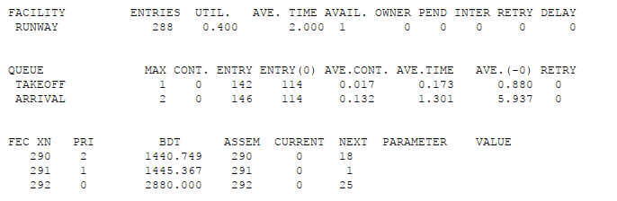

Отчёт модели работы аэропорта

## Модель работы морского порта

Морские суда прибывают в порт каждые (a ± δ) часов. В порту имеется N причалов. Каждый корабль по длине занимает M причалов и находится в порту (b ± ε) часов. Требуется построить GPSS-модель для анализа работы морского порта в течение полугода, определить оптимальное количество причалов для эффективной работы порта. Исходные данные: 1) a = 20 ч, δ = 5 ч, b = 10 ч, ε = 3 ч, N = 10, M = 3; 2) a = 30 ч, δ = 10 ч, b = 8 ч, ε = 4 ч, N = 6, M = 2.

## Модель работы морского порта

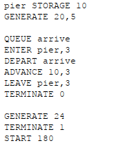

Модель работы морского порта

## Модель работы морского порта

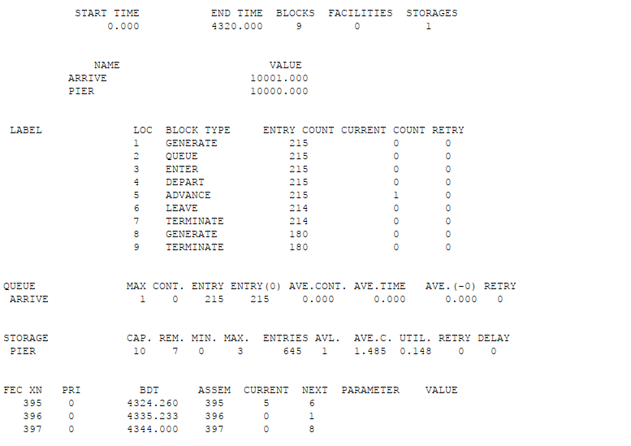

Отчёт модели работы морского порта

## Модель работы морского порта

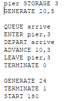

Модель работы морского порта

## Модель работы морского порта

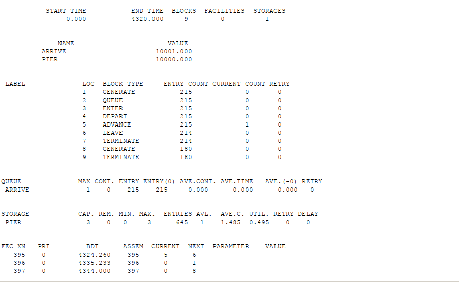

Отчёт модели работы морского порта

## Модель работы морского порта

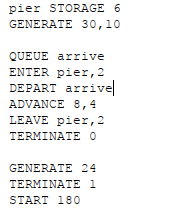

Модель работы морского порта

## Модель работы морского порта

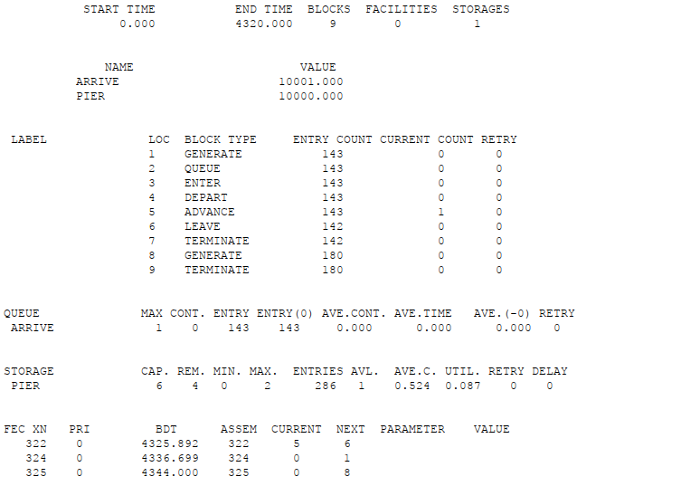

Отчёт модели работы морского порта

## Модель работы морского порта

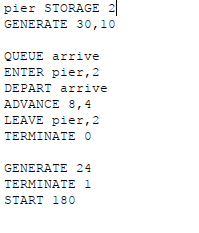

Модель работы морского порта

## Модель работы морского порта

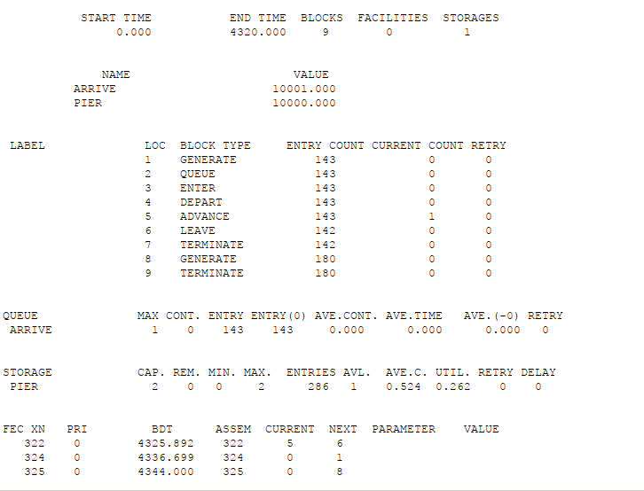

Отчёт модели работы морского порта

## Выводы

Я выполнила задания для самостоятельного выполнения.

Спасибо за внимание!